## Introduction

> *Basic Definition: style of art that makes use of shapes, textures, colors and forms to create compositions that have limited or no resemblance to features in external reality.

> *Examples:

[figure not shown]

## Current Modes of Observing Abstract Art

> *Obtaining your own pieces: items are rare and costly (with some going for as much as $100 million!)

> *Going to an art museum: difficult to access if you dont live in a large area, dealing with crowds

> *Internet: pieces are scaled down, limited resolution

## The Alternative is Here: Butchie’s Abstract Art Generator!

> *Interactive means to produce beautiful works of abstract art via Shiny

> *Process is fast and fun: user specifies 3 inputs, presses submit and a masterpiece is generated in seconds

> *Each composition is unique

> *The app. is totally FREE!

## Demo (Full Product: butchie.shinyapps.io/Abstract)

> *Embedded Input:

```r
#Inputs
color <- "blue"
fillers <- 600
features <-"blue"
```

> *Embedded Output:

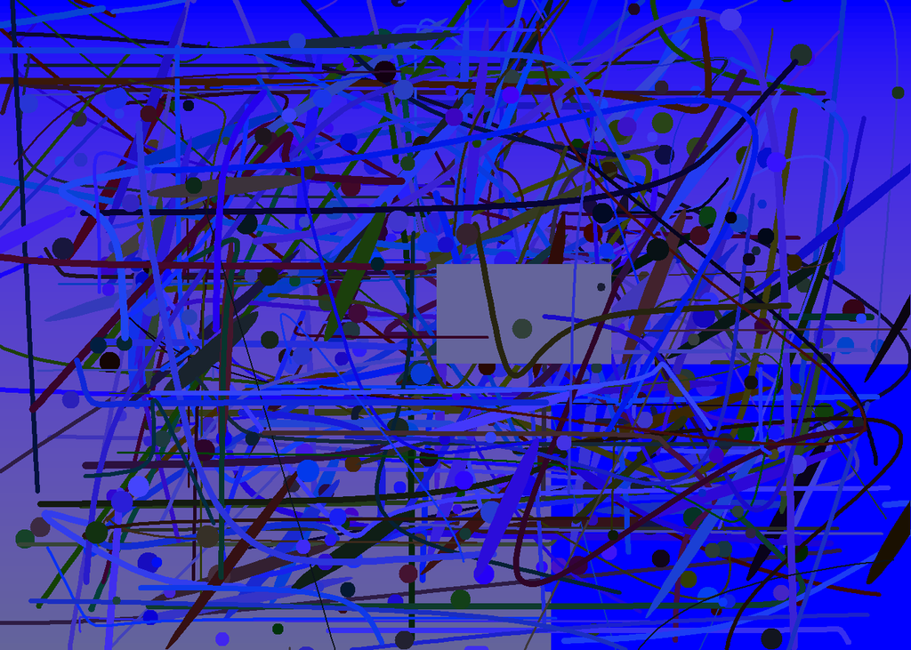